# Modelování nelineárních vztahů pomoc splines

19 4 2021

## Motivační příklad

- V praxi jsou nelineární vztahy mezi proměnnými běžné

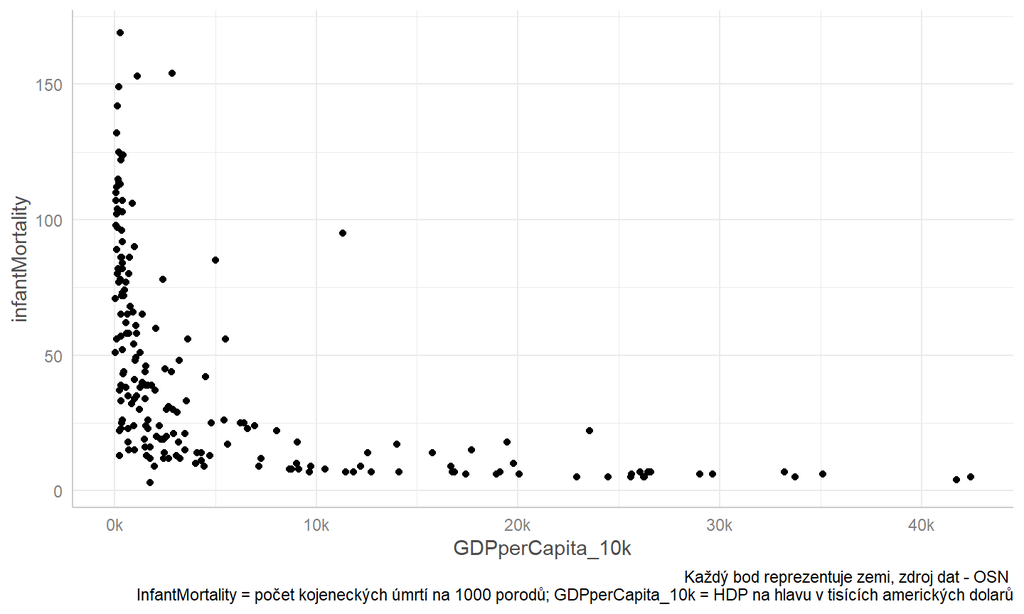

## Klasické modelování nelinearity

- Kromě specifických případů jsou v sociologii nejpopulárnější dvě techniky:
  - Kategorizace
  - Jednoduché polynomické funkce (např. kvadratická regrese)
- Obě tyto techniky ale provází řada problémů

## Kategorizace

- Numerická proměnná je převedena do sady diskrétních kategorií

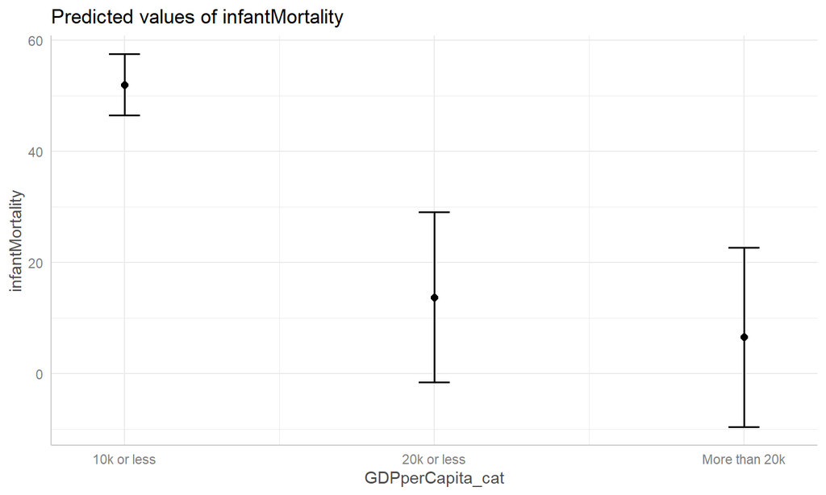

## Problémy kategorizace

- Kategorizované prediktory jsou jednoduše interpretovatelné
- Ale řada technických problémů (Harrell 2001):
  - Predikce mají nižší preciznost, testy nižší statistickou sílu
  - Předpoklad, že všechny pozorování uvnitř intervalu mají stejnou hodnotu závislé proměnné
  - Předpoklad skokových změn při přechodu mezi intervaly
  - Hranice intervalů jsou arbitrátní a manipulovatelné

## Problémy kategorizace

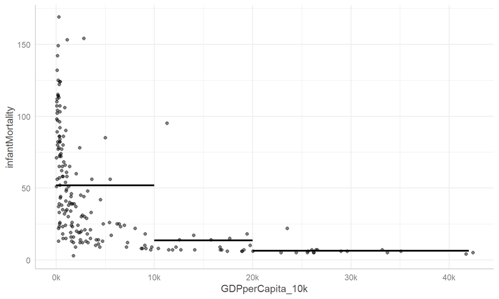

## Jednoduché polynomy

- Numerická proměnná modelováná pomocí polynomické funkce (např. GDPperCapita<sup>2</sup>):

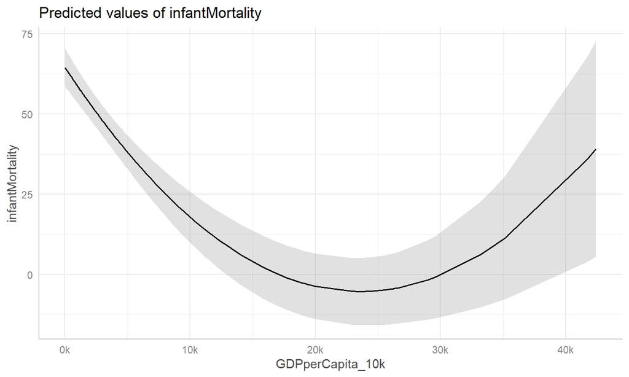

## Problémy jednoduchých polynomů

- Polynomy můžou podchytit nelineární vztahy bez nutnosti kategorizovat
- Mají ovšem svoje vlastní problémy:
  - Dokaží zachytit jen určitý typ nelinearity (ten polynomický)
  - Extrémně nestabilní na okrajích dat, mají tendenci se “kroutit”

## Problémy jednoduchých polynomů

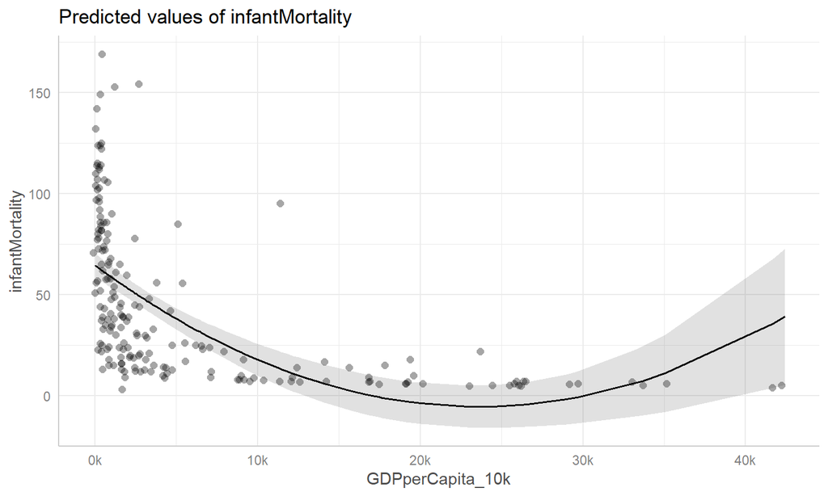

## Spliny

- Existuje lepší technika, než kategorizace a jednoduché polynomy?
  - Spliny (zvané též piecewise regrese)
- Základní myšlenka splinů je jednoduchá:
  - Místo prokládání jedné přímky/křivky napříč celým rozsahem dat, si data rozdělíme na menší úseky (*bins*) a proložíme přímku/křivku každým zvlášť tak, aby na sebe navazovaly
  - hranicím mezi úseky se říká uzly (*knots*)
- Technické detaily viz Harrell (2001) nebo Fox (2015)

## Lineární spliny

- Nejjednoduší forma splinů - úseky je proložená přímka

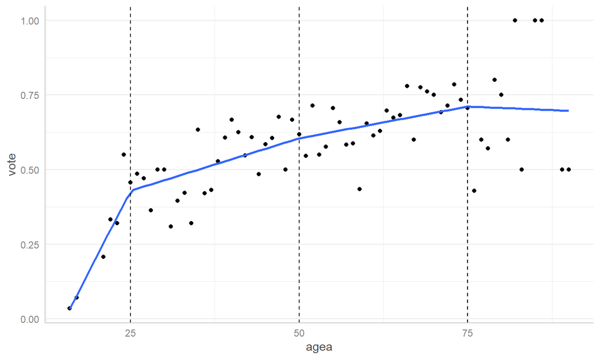

Example of spline function, dividing data into 4 bins

## Lineární spliny

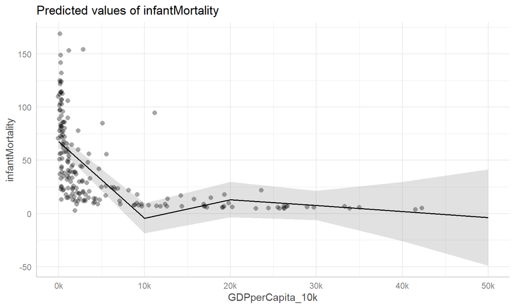

## Lineární spliny

- Lepší forma kategorizace (méně nerealistických předpokladů), pořád dobře interpretovatelné

| Term | Estimate | SE | t statistic | p value |
| --- | --- | --- | --- | --- |
| Intercept | 67.68 | 3.15 | 21.48 | 0.00 |
| GDPperCapita (<10k) | -7.21 | 0.88 | -8.14 | 0.00 |
| GDPperCapita (10k<x<20k) | 1.75 | 1.22 | 1.44 | 0.15 |
| GDPperCapita (<20k) | -0.56 | 0.94 | -0.59 | 0.55 |

- Regresní koeficienty představují jednoduše sklon regresní přímky v daném úseku

## Přirození spliny

- Lineární spliny nemají nerealistické předpoklady o konstantní hodnotě uvnitř intervalu, pořád ale předpokládají náhlou změnu vztahu v určitých hodnotách (uzlech) a jsou citlivé na pozici uzlů
- Existuje ještě flexibilnější metoda?
- Ano! Polynomické spliny
  - Konkrétně, přirozené spliny (*natural splines*), někdy zvané omezené kubické spliny (*restricted cubic splines*)

## Přirozené spliny

- Řeší oba problémy jednoduchých polynomů
  - Ve vnitřních úsecích prokládají několik na sebe navazujících křivek, čímž dokáží postihnout téměř jakkoukoliv formu nelinearity
  - V krajních úsecích prokládají přímky, čímž se stabilizují predikce

## Přirozené spliny

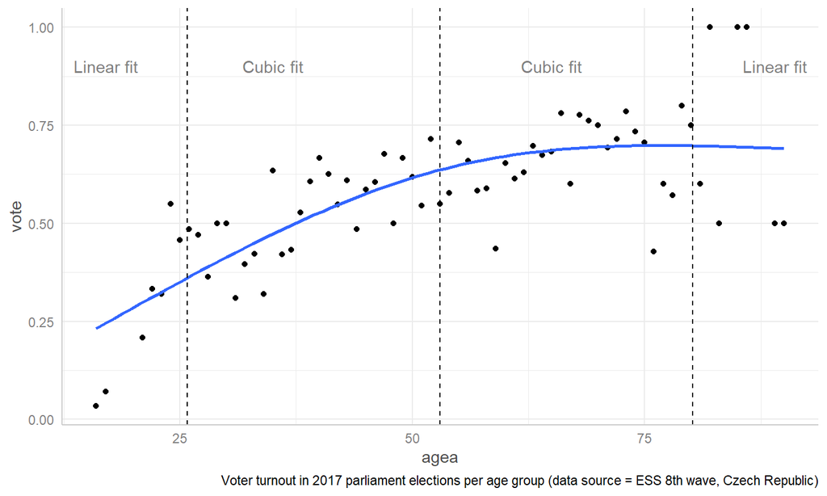

## Přirozené spliny

- Přirozené spliny na našich datech (4 uzly, 2 vnitřní a 2 vnější)

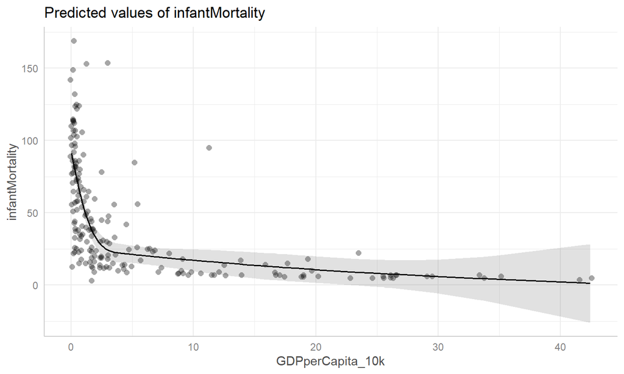

## Přirozené spliny

- Jeden z nejflexibilnějších nástrojů pro modelování nelineárních vztahů v kontextu lineárních modelů
- Nevýhodou je, že (stejně jako jednoduché polynomy) je v podstatě nemožné interpretovat regresní koeficienty

| Term | Estimate | SE | t statistic | p value |
| --- | --- | --- | --- | --- |
| Intercept | 91.19 | 4.18 | 21.82 | 0 |
| GDPperCapita (<10k), cubic | -53.79 | 11.51 | -4.67 | 0 |
| GDPperCapita (10k<x<20k), cubic | -140.50 | 10.79 | -13.02 | 0 |
| GDPperCapita (<20k), cubic | -61.20 | 13.79 | -4.44 | 0 |

## Pozice uzlů

- Poslední otázka: Jak rozmístit uzly?
- Lineární spliny velmi citlivé na pozici uzlů (stejně jako klasická kategorizace) -> uzly rozmisťovat na základě teorie
- Přirozené spliny naopak velmi robustní
  - Dokud jsou uzly rozmístěny rovnoměrně, jejich pozice je méně důležitá
  - Primární je jejich počet

## Pozice uzlů přirozených splinů

- V praxi většinou stačí 3-4 uzly (2 krajní a 1-2 vnitřní)
- Každý uzel je jeden parametr v modelu -> můžeme zkusit několik modelů a vybrat ten s nejlepším penalizovaným fitem (adj. R<sup>2</sup>, AIC)
- Optimální pozice uzlů podle jejich počtu (Harrell 2001, 27) :

| Uzly |  |  | Kvantil |  |  |  |  |
| --- | --- | --- | --- | --- | --- | --- | --- |
| 3 |  | 0.1 | 0.5 | 0.9 |  |  |  |
| 4 |  | 0.05 | 0.35 | 0.65 | 0.95 |  |  |
| 5 |  | 0.05 | 0.275 | 0.5 | 0.725 | 0.95 |  |
| 6 | 0.05 | 0.23 | 0.41 | 0.59 | 0.77 | 0.95 |  |
| 7 | 0.025 | 0.1833 | 0.33417 | 0.5 | 0.6583 | 0.8167 | 0.975 |

## Spliny v R

- Balíček `lsplines` pro lineární spliny
- Balíček `splines` pro přirozené spliny (a všechny ostatní)
- Měli by fungovat se všemi funkcemi založenými na `stats::glm()`

## R inteRmezzo!

## Srovnání splinů s ostatními metodami

| Technika | Výhody | Nevýhody |
| --- | --- | --- |
| Kategorizace | Velmi jednoduchá interpretace | Nerealistické předpoklady, citlivá na umístění uzlů |
| Lineární spliny | Jednoduchá interpretace | předpoklad náhlých změn, citlivá na umístění uzlů |
| Jednoduché polynomy | ? | Omezená na určité typy nelinearity, nestabilní na okrajích, nutné interpretovat graficky |
| Přirozené spliny | Dokaží pokrýt řadu nelineárních vztahů | Nutné interpretovat graficky |

## Srovnání přirozených splinů s polynomickými členy

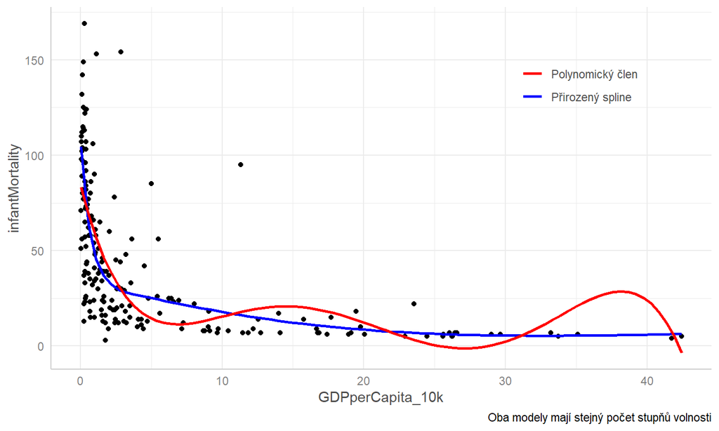

## Spliny jinde

- STATA - funkce `mkspline`
- SPSS - nemá vlastní funkci, nutné počítat [“ručně”](https://www.ibm.com/support/pages/spline-regression-aka-piecewise-polynomials-or-segmented-regression)

## Závěrem

- Materiály k semináři dostupné na githubu: https://github.com/alesvomacka/workshop_splines
- Použitá data původně z knihy Applied Regression Analysis and Generalized Linear Models od Johna Foxe. Popis proměnných [zde](https://socialsciences.mcmaster.ca/jfox/Books/Applied-Regression-3E/datasets/UnitedNations.pdf).

## Děkuji za pozornost!

## Reference

Fox, John. 2015. *Applied Regression Analysis and Generalized Linear Models*. Third edition. Los Angeles: SAGE Publications, Inc.

Harrell, Frank. 2001. *Regression Modeling Strategies: With Applications to Linear Models, Logistic Regression, and Survival Analysis*. Springer Series in Statistics. New York: Springer-Verlag. https://doi.org/10.1007/978-1-4757-3462-1.